# Projet de Machine Learning

Cyprien Ferraris (ISDS) Vincent Le Goualher (ISDS) Paul Malfrait (ISDS) Margaux Morin (ISDS)

```python
fn1 = "Cyprien"
ln1 = "Ferraris"
fn2 = "Vincent"
ln2 = "LeGoualher"
fn3 = "Paul"
ln3 = "Malfrait"
fn4 = "Margaux"
ln4 = "Morin"

filename = "_".join(map(lambda s: s.strip().lower(),
                        ["project", ln1, fn1, "", ln2, fn2, "", ln3, fn3,
                        "and", ln4, fn4])) + ".ipynb"
print(filename)
```

```
project_ferraris_cyprien__legoualher_vincent__malfrait_paul_and_morin_margaux.ipynb
```

In the Machine Learning project, we chose to work on image recognition of the sign language alphabet.

The database used comes from Kaggle, and provides us with two .csv files (one for training and one for testing) that contain the pixel description of each image.

The training file provides data for 27455 images and the test file for 7172 images. The letters J and Z are not represented in the image because they are movements.

Each image consists of 784 pixels with a value from 0 to 255, corresponding to the gray level of the pixel.

The images correspond to the rows of the data tables, they are called by a label ranging from 0 (for the letter A) to 24 (for the letter Y), and the pixels of the images correspond to the columns.

#### Image provided with the data

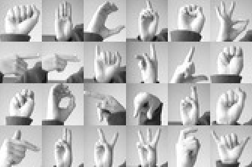

```python
from IPython.display import Image
Image(filename = "/content/amer_sign3.png")
```

The **goal** of this project is to find the best Machine Learning tool allowing the recognition of a letter of the alphabet by showing any photo representing a letter in sign language.

In a first step we will test the most classical clustering methods with Scikit-Learn :

- Kmeans
- DSCAN
- SpectralClustering

Next we will test the SVM using the Scikit-Learn library.

Then the following assembly methods still with Scikit-Learn :

- Decision trees
- Bagging
- Bosting
- Extra Trees
- Random Forest

Finally we tested the neural networks with the Keyras library integrated in TensorFlow :

## Introduction

First of all we make the orders to view our datasets.

**Upload of librairies and packages**

The notebook was launched on google colab with a GPU as accelerator (execution - change the execution type) And version 2 of tensorflow

```python
try:
  # %tensorflow_version only exists in Colab.
  %tensorflow_version 2.x
except Exception:
  pass

import tensorflow as tf
tf.__version__
```

```
'2.1.0-rc1'
```

```python
import numpy as np
import pandas as pd
import matplotlib.pyplot as plt
%matplotlib inline
import scipy.stats as sps
import warnings
warnings.filterwarnings('ignore')

from tensorflow.keras import layers, optimizers, losses, backend, utils
from tensorflow.keras.models import Sequential
from tensorflow.keras.layers import Dense, Activation, Flatten, Dropout, SpatialDropout2D
from tensorflow.keras.optimizers import SGD
from tensorflow.keras.layers import Conv2D, MaxPooling2D
from tensorflow.keras.activations import linear
```

**Upload of data**

Before starting the algorithm you have to separate the labels from the data and put them in the right form for the use of ScikitLearn and Tensorflow.

// a supprimer sign_test = pd.read_csv("sign_mnist_test.csv", sep = ",",index_col = 0) sign_train = pd.read_csv("sign_mnist_train.csv", sep = ",",index_col = 0)

```python
sign_test = pd.read_csv("/content/sign_mnist_test.csv", sep = ",",index_col = 0)
sign_train = pd.read_csv("/content/sign_mnist_train.csv", sep = ",",index_col = 0)
```

**Description**

```python
print(sign_test.shape)
print(sign_train.shape)
```

```
(7172, 784)
(27455, 784)
```

```python
print(sign_train.head(10))
```

```
       pixel1  pixel2  pixel3  pixel4  ...  pixel781  pixel782  pixel783  pixel784
label                                  ...
3         107     118     127     134  ...       206       204       203       202
6         155     157     156     156  ...       175       103       135       149
2         187     188     188     187  ...       198       195       194       195
2         211     211     212     212  ...       225       222       229       163
13        164     167     170     172  ...       157       163       164       179
16        161     168     172     173  ...        48       238       255       255
8         134     134     135     135  ...       179       181       181       179
22        114      42      74      99  ...       227       227       228       228
3         169     174     176     180  ...        94        74        61        57
3         189     189     189     190  ...       193       175       178       156

[10 rows x 784 columns]
```

```python
print(sign_test.describe())
```

```
            pixel1       pixel2  ...     pixel783     pixel784
count  7172.000000  7172.000000  ...  7172.000000  7172.000000
mean    147.532627   150.445761  ...   156.664250   154.776771
std      43.593144    41.867838  ...    67.202939    68.285148
min       0.000000     0.000000  ...     0.000000     0.000000
25%     122.000000   126.000000  ...   111.000000   106.750000
50%     154.000000   157.000000  ...   180.000000   179.000000
75%     178.000000   179.000000  ...   206.000000   204.000000
max     255.000000   255.000000  ...   255.000000   255.000000

[8 rows x 784 columns]
```

```python
print(sign_train.shape)
```

```
(27455, 784)
```

```python
sign_train.index
sign_test.index
```

```
Int64Index([ 6,  5, 10,  0,  3, 21, 10, 14,  3,  7,
            ...
            10,  4, 14,  8, 12,  1, 12,  2,  4,  2],
           dtype='int64', name='label', length=7172)
```

```
[]
```

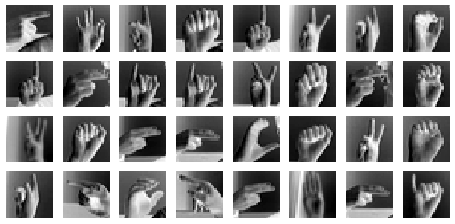

```python
def reshape_to_2d(data, dim):
    reshaped = []
    labs = data[:,0]
    data = data[:,1:]
    for row in data :
        reshaped.append( row.reshape(dim, dim) )
    return ( labs,np.array(reshaped) )

train_lab, train_data_2D = reshape_to_2d(np.array(pd.read_csv("sign_mnist_test.csv")), 28)
test_lab, test_data_2D = reshape_to_2d(np.array(pd.read_csv("sign_mnist_train.csv")), 28)


n_rows = 4
n_cols = 8
plt.figure(figsize=(8, 4))
for i in range(n_rows * n_cols):
    plt.subplot(n_rows, n_cols, i+1)
    plt.imshow(train_data_2D[i],
               interpolation="none", cmap="gray_r")
    plt.axis("off")
plt.tight_layout()
plt.plot()
```

## Part 1 : Classic clustering methods

### Kmeans

Use of scikit-learn package for the use of the Kmeans algorithm

The k-means method is a data partitioning method.

The k-means are used in unsupervised learning where observations are divided into k partitions. Given points and an integer k, the problem is to divide the points into k groups, often called clusters, in order to minimize a certain function. We consider the distance from a point to the average of the points in its cluster; the function to be minimized is the sum of the squares of these distances.

```python
from sklearn import cluster
kmeans = cluster.KMeans(n_clusters=24)
kmeans.fit(sign_train)
#index triés des groupes
idk = np.argsort(kmeans.labels_)
idk
```

```
array([ 9200, 21482, 12125, ..., 13193,  1876,  1685])
```

```python
#affichage des observations et leurs groupes
print(pd.DataFrame(sign_train.index[idk],kmeans.labels_[idk]))
```

```
    label
0      12
0      24
0       0
0       0
0       4
..    ...
23     23
23     15
23      5
23     16
23     15

[27455 rows x 1 columns]
```

```
[ 0.16971953  1.          2.          3.          4.          5.
  6.          7.          8.          9.         10.         11.
 12.         13.         14.         15.         16.         17.
 18.         19.         20.         21.         22.         23.
 24.         25.        ]
[ 0.16971953  0.10676283  2.          3.          4.          5.
  6.          7.          8.          9.         10.         11.
 12.         13.         14.         15.         16.         17.
 18.         19.         20.         21.         22.         23.
 24.         25.        ]
[ 0.16971953  0.10676283  0.1137816   3.          4.          5.
  6.          7.          8.          9.         10.         11.
 12.         13.         14.         15.         16.         17.
 18.         19.         20.         21.         22.         23.
 24.         25.        ]
[ 0.16971953  0.10676283  0.1137816   0.08989454  4.          5.
  6.          7.          8.          9.         10.         11.
 12.         13.         14.         15.         16.         17.
 18.         19.         20.         21.         22.         23.
 24.         25.        ]
[ 0.16971953  0.10676283  0.1137816   0.08989454  0.08288581  5.
  6.          7.          8.          9.         10.         11.
 12.         13.         14.         15.         16.         17.
 18.         19.         20.         21.         22.         23.
 24.         25.        ]
[ 0.16971953  0.10676283  0.1137816   0.08989454  0.08288581  0.07273474
  6.          7.          8.          9.         10.         11.
 12.         13.         14.         15.         16.         17.
 18.         19.         20.         21.         22.         23.
 24.         25.        ]
[ 0.16971953  0.10676283  0.1137816   0.08989454  0.08288581  0.07273474
  0.07614262  7.          8.          9.         10.         11.
 12.         13.         14.         15.         16.         17.
 18.         19.         20.         21.         22.         23.
 24.         25.        ]
[ 0.16971953  0.10676283  0.1137816   0.08989454  0.08288581  0.07273474
  0.07614262  0.06759247  8.          9.         10.         11.
 12.         13.         14.         15.         16.         17.
 18.         19.         20.         21.         22.         23.
 24.         25.        ]
```

[output cut: 75 more lines]

```
[ 0.16971953  0.10676283  0.1137816   0.08989454  0.08288581  0.07273474
  0.07614262  0.06759247  0.06224131  0.0789596   0.06951724  0.06816361
  0.06899607  0.07048796  0.06654453  0.06073219  0.06521101  0.06047119
  0.06479667  0.06250834  0.06143613  0.06096372  0.06242741  0.06159282
 24.         25.        ]
[ 0.16971953  0.10676283  0.1137816   0.08989454  0.08288581  0.07273474
  0.07614262  0.06759247  0.06224131  0.0789596   0.06951724  0.06816361
  0.06899607  0.07048796  0.06654453  0.06073219  0.06521101  0.06047119
  0.06479667  0.06250834  0.06143613  0.06096372  0.06242741  0.06159282
  0.06246554 25.        ]
[0.16971953 0.10676283 0.1137816  0.08989454 0.08288581 0.07273474
 0.07614262 0.06759247 0.06224131 0.0789596  0.06951724 0.06816361
 0.06899607 0.07048796 0.06654453 0.06073219 0.06521101 0.06047119
 0.06479667 0.06250834 0.06143613 0.06096372 0.06242741 0.06159282
 0.06246554 0.0626561 ]
```

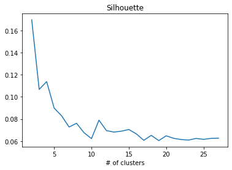

```python
#librairie pour évaluation des partitions
from sklearn import metrics
#utilisation de la métrique "silhouette"
res = np.arange(26,dtype="double")
for k in np.arange(26):
    km = cluster.KMeans(n_clusters=k+2)
    km.fit(sign_train)
    res[k] = metrics.silhouette_score(sign_train,km.labels_)
    print(res)
#graphique
import matplotlib.pyplot as plt
plt.title("Silhouette")
plt.xlabel("# of clusters")
plt.plot(np.arange(2,28,1),res)
plt.show()
```

The Silhouette index is a way to evaluate the validity of a clustering. According to this, the best clustering is the one with the greatest index. One sees here that the method (analyzed by the Silhouette index) is not able to find the true structure of the data.

```python
result = np.zeros((24,24))
for i in range(sign_train.shape[0]):
  true_index = sign_train.index[idk][i]
  estimate_index = kmeans.labels_[idk][i]
  result[true_index-1,estimate_index] += 1

print(result)
```

```
[[  0.   5.   0.  75. 207.  86.  80.  78.  11.  47.   0.   0.  44.  70.
    0.   0.  87.   1. 117.  62.  33.   0.   0.   7.]
 [ 11.   4. 136.   0.   4.   0.   0.   8.   0.   0.   0. 475.   0.   0.
    7.  58.   0.   0.   0.   0.  19. 211. 207.   4.]
 [ 78.  75.  11. 120. 137.  85.  76.  38.   6.  19.  13.   0.  88.  76.
    0.  30. 122.  27.  96.  58.  13.   0.  17.  11.]
 [149.  26.   2.  54.   9.  34.   0. 219.   0.   0.   0.   0.  23.   0.
    0.   0.  30. 102.  97.  41. 156.   0.   8.   7.]
 [108.  51.  66.  52. 104.  57.  51.  53.   4.   0.  84.  29. 110.  37.
    0.  90.  34.  13.  44.  50.  53.   0. 103.  11.]
 [  0.  89. 124.   0.   2.   5.   0.   1.   5.   0. 228.   0.   3.  18.
  193. 209.  88.   0.  10.   7.   1.   0. 107.   0.]
 [ 20. 104. 115.   0.  23.   3.   8.   3.  13.   0. 169.   0.  32.   3.
  216. 144.  26.   0.  41.  23.   0.   0.  70.   0.]
 [ 58. 115.   3. 126. 118. 123.  13. 104.   1.  32.   0.   0.  55.  33.
    0.   0. 114.  17.  90.  76.  67.  14.   0.   3.]
 [  0.   0.   0.   0.   0.   0.   0.   0.   0.   0.   0.   0.   0.   0.
    0.   0.   0.   0.   0.   0.   0.   0.   0.   0.]
 [  0.  22.  11. 140.  34.  89. 328.   0.   0.   0.   0.   0. 132. 153.
    0.  31.   0.   0.  22.  42.   0.   0.   3. 107.]
 [  0.  82. 164.  45.  97.  54.   6.   0.   0.   0.  87.   4.  56.  36.
    0. 387.  16.   0.  41.  44.   0.   0. 120.   2.]
 [ 37.   0.   0. 101.  54.  48.   3. 193.  22.   6.   9.   0.  39.   9.
    0.  15.  68.  44. 105.  38. 222.   0.  39.   3.]
 [ 55.  20.  10. 117.  43.  45.  21. 143.   8.   0.  78.   0.  55.  39.
    0.  17.  54.  82.  61.  45. 213.  11.  34.   0.]
 [ 16.   0. 101.   0.  55.  11.   0. 123.   0.   0.  22. 316.   0.   0.
    2.  60.   0.   4.  72.  11. 177.  40. 180.   6.]
 [  1.   7.   0.  67.  88.  20.   1.   0. 422.  54.   0.   0.  43.   0.
    0.   4.  41.   0. 105.   0.   0.   0.  36. 199.]
 [124.  27.  27.  45.  40.  21.   0.  21. 296.  24.  13.   0.  39.   1.
   68.  40.  17.   6. 106.   6.  24.   0.  97. 237.]
 [  0.  72.   5. 148. 128. 146.  43.   0.   5.  78.   0.   0. 187. 277.
    0.   0.  84.   0.  45.  67.   0.   0.   5.   4.]
 [  0.   3.   2. 221.  45. 128.  16. 177.  23.  21.   7.   0.  46.  25.
    0.   0.  79.   0.  76.  83. 213.   0.  20.  14.]
 [ 10. 113. 245.   0.  14.   3.   0.   7.   0.   0.  72.   0.  20.  50.
   90. 347.  11.   1.   6.  87.   3.   0. 107.   0.]
 [  1.  83.  12. 172. 139. 173.  83.   0.  21.  68.   0.   0.  83. 157.
    0.  10.   3.   0.  82.  49.   1.   0.  12.  12.]
 [  0.  57.  30.  88. 113. 110.  18.   6.  10.  73.  17.   0. 108. 234.
    0.  39.  22.   0.  39.  99.   4.   0.  15.   0.]
 [  0.  88.   5. 131.  69. 162. 132.   0.  18.  86.  12.   0. 148. 187.
    0.  29.  21.   0.  35.  67.   0.   0.   5.  30.]
 [ 17.  46. 100.  21. 195.  60.  50.  10.   5.  31.  89.   0.  87.  53.
    0. 141.  40.   0.  67.  74.   7.   0.  40.  31.]
 [ 51.  97.  75. 127.  46. 110.  81. 346.   8.  72.  19.   0. 131. 124.
    0. 155.   6.  92. 135. 112. 367.   0.  55.  35.]]
```

If the algorithm worked, we would have on each line, a very high value and the other values equal to zero or very low, which would mean that each "letter" corresponds to a class. We can see very clearly that this is not the case here.

### DSCAN

The DBSCAN (density-based spatial clustering of applications with noise) algorithm uses two parameters: distance $\epsilon$ and the minimum number of points *MinPts* that must be within a radius $\epsilon$ for those points to be considered a cluster.

The input parameters are therefore an estimate of the point density of the clusters.The basic idea of the algorithm is then, for a given point, to retrieve its $\epsilon$-neighborhood and check that it contains *MinPts* points or more.

That point is then considered part of a cluster. The $\epsilon$-neighborhood is then scanned step by step in order to find all the points of the cluster.

```python
from sklearn.cluster import DBSCAN

clustering = DBSCAN(eps=23, min_samples=2).fit(sign_test)
print(clustering.labels_)
```

```
[-1 -1 -1 ... -1 -1 -1]
```

```python
from scipy import stats
stats.describe(clustering.labels_)
```

```
DescribeResult(nobs=7172, minmax=(-1, 344), mean=15.874930284439486, variance=3590.6652924927, skewness=3.7932060879872362, kurtosis=13.72047420925523)
```

```python
nb_par_cluster = np.zeros(346)
for i in range(-1,345):
    nb_par_cluster[i+1] = sum(clustering.labels_ == i)

print(nb_par_cluster)
```

```
[6.467e+03 2.000e+00 2.000e+00 2.000e+00 3.000e+00 2.000e+00 2.000e+00
 2.000e+00 2.000e+00 2.000e+00 2.000e+00 2.000e+00 3.000e+00 2.000e+00
 2.000e+00 2.000e+00 2.000e+00 2.000e+00 2.000e+00 2.000e+00 2.000e+00
 2.000e+00 2.000e+00 2.000e+00 2.000e+00 2.000e+00 2.000e+00 2.000e+00
 2.000e+00 2.000e+00 2.000e+00 2.000e+00 3.000e+00 2.000e+00 2.000e+00
 2.000e+00 2.000e+00 2.000e+00 2.000e+00 2.000e+00 2.000e+00 2.000e+00
 2.000e+00 2.000e+00 2.000e+00 2.000e+00 2.000e+00 2.000e+00 2.000e+00
 2.000e+00 2.000e+00 2.000e+00 3.000e+00 2.000e+00 2.000e+00 2.000e+00
 2.000e+00 2.000e+00 2.000e+00 2.000e+00 2.000e+00 3.000e+00 3.000e+00
 2.000e+00 3.000e+00 2.000e+00 2.000e+00 2.000e+00 2.000e+00 2.000e+00
 2.000e+00 2.000e+00 2.000e+00 2.000e+00 2.000e+00 3.000e+00 2.000e+00
 2.000e+00 2.000e+00 2.000e+00 2.000e+00 2.000e+00 2.000e+00 2.000e+00
 3.000e+00 2.000e+00 2.000e+00 2.000e+00 2.000e+00 2.000e+00 2.000e+00
 2.000e+00 2.000e+00 2.000e+00 2.000e+00 2.000e+00 2.000e+00 2.000e+00
 2.000e+00 2.000e+00 2.000e+00 2.000e+00 2.000e+00 2.000e+00 2.000e+00
 2.000e+00 2.000e+00 2.000e+00 2.000e+00 2.000e+00 2.000e+00 2.000e+00
 2.000e+00 2.000e+00 2.000e+00 2.000e+00 2.000e+00 2.000e+00 2.000e+00
 2.000e+00 2.000e+00 2.000e+00 2.000e+00 2.000e+00 2.000e+00 2.000e+00
 2.000e+00 2.000e+00 2.000e+00 2.000e+00 2.000e+00 2.000e+00 2.000e+00
 2.000e+00 3.000e+00 3.000e+00 2.000e+00 2.000e+00 2.000e+00 2.000e+00
 2.000e+00 2.000e+00 2.000e+00 2.000e+00 2.000e+00 2.000e+00 2.000e+00
 2.000e+00 2.000e+00 2.000e+00 2.000e+00 2.000e+00 2.000e+00 2.000e+00
 3.000e+00 2.000e+00 2.000e+00 2.000e+00 2.000e+00 2.000e+00 2.000e+00
 2.000e+00 2.000e+00 2.000e+00 2.000e+00 2.000e+00 2.000e+00 2.000e+00
 2.000e+00 2.000e+00 2.000e+00 2.000e+00 2.000e+00 2.000e+00 2.000e+00
 2.000e+00 2.000e+00 2.000e+00 2.000e+00 2.000e+00 2.000e+00 2.000e+00
 2.000e+00 2.000e+00 2.000e+00 2.000e+00 2.000e+00 2.000e+00 2.000e+00
 2.000e+00 2.000e+00 2.000e+00 2.000e+00 2.000e+00 2.000e+00 2.000e+00
 2.000e+00 2.000e+00 2.000e+00 2.000e+00 2.000e+00 2.000e+00 2.000e+00
 2.000e+00 2.000e+00 2.000e+00 2.000e+00 2.000e+00 2.000e+00 2.000e+00
 2.000e+00 2.000e+00 2.000e+00 2.000e+00 2.000e+00 2.000e+00 2.000e+00
 2.000e+00 2.000e+00 2.000e+00 2.000e+00 2.000e+00 2.000e+00 2.000e+00
 2.000e+00 2.000e+00 2.000e+00 2.000e+00 2.000e+00 2.000e+00 2.000e+00
 2.000e+00 2.000e+00 2.000e+00 2.000e+00 2.000e+00 2.000e+00 2.000e+00
 2.000e+00 3.000e+00 2.000e+00 2.000e+00 2.000e+00 2.000e+00 2.000e+00
 2.000e+00 2.000e+00 2.000e+00 2.000e+00 2.000e+00 2.000e+00 2.000e+00
 2.000e+00 2.000e+00 2.000e+00 2.000e+00 2.000e+00 2.000e+00 2.000e+00
 2.000e+00 2.000e+00 2.000e+00 2.000e+00 2.000e+00 2.000e+00 2.000e+00
 3.000e+00 2.000e+00 2.000e+00 2.000e+00 2.000e+00 2.000e+00 2.000e+00
 2.000e+00 2.000e+00 2.000e+00 2.000e+00 2.000e+00 2.000e+00 2.000e+00
 2.000e+00 2.000e+00 2.000e+00 3.000e+00 2.000e+00 2.000e+00 2.000e+00
 2.000e+00 2.000e+00 2.000e+00 2.000e+00 2.000e+00 2.000e+00 2.000e+00
 2.000e+00 2.000e+00 2.000e+00 2.000e+00 2.000e+00 2.000e+00 2.000e+00
 2.000e+00 2.000e+00 2.000e+00 2.000e+00 2.000e+00 2.000e+00 2.000e+00
 2.000e+00 2.000e+00 2.000e+00 2.000e+00 2.000e+00 2.000e+00 2.000e+00
 2.000e+00 2.000e+00 2.000e+00 2.000e+00 2.000e+00 2.000e+00 2.000e+00
 2.000e+00 2.000e+00 2.000e+00 2.000e+00 2.000e+00 2.000e+00 2.000e+00
 2.000e+00 2.000e+00 2.000e+00 2.000e+00 2.000e+00 2.000e+00 2.000e+00
 2.000e+00 2.000e+00 2.000e+00 2.000e+00 2.000e+00 2.000e+00 2.000e+00
 2.000e+00 2.000e+00 2.000e+00]
```

We can see that most of the dataset samples do not have an assigned cluster. They are assigned -1, which corresponds to noise. So we can't use this clustering method to identify our letters.

### Spectral Clustering

Spectral cluste is a K-group partitioning method based on minimizing a "slice" criterion. These two measures express the internal cohesion of the groups, relative to their dissociation from each other. They are directly functions of a matrix of similarities between objects, noted S.

Given a set of N objects, it is possible to obtain a detailed representation of this set in the form of a weighted graph, noted G(V,E,S). V denotes the set of N nodes of the graph, corresponding to the objects; E is the set of inter-node arcs and S is the weight matrix of the arcs (similarity matrix), symmetrical and non-negative.

We use the test set for this clustering, because the training set doesn't work, as it is probably too heavy.

```python
from sklearn.cluster import SpectralClustering

clustering = SpectralClustering(n_clusters=24,assign_labels="discretize",random_state=0).fit(sign_test)
clustering.labels_
```

```
array([0, 0, 0, ..., 0, 0, 0])
```

The structure of the data is not understood by the algorithm, that is why we obtain only one cluster with this method.

## Part 2 : SVM

In this part of the project we are going to use de SVM methods from the sk_learn library. Several methods are available with different kernels end different separation scheme.

First we are looking at the two ways we can separate data: "one vs one" and "one vs the rest". On the one hand we are creating (N_class*(N_class-1))/2 classifiers looking at every couple of categories. We then aggregate the results to create the final classifier. On the second hand we are using the "one vs the rest" method, creating N_class classifiers considering each category in front of the rest of the data and the, as before, aggregating the classifiers.

These two methods lead to the same results in the end. In fact the structures that are caught with the two methods are the same resulting in the same score.

```python
import pandas as pd

sign_train = pd.read_csv("/content/sign_mnist_train.csv")
sign_test = pd.read_csv("/content/sign_mnist_test.csv")

# Échantillon d'apprentissage
X_train = sign_train.iloc[:, 1:].values
y_train = sign_train.iloc[:, 0].values

# Échantillon de validation
X_test = sign_test.iloc[:, 1:].values
y_test = sign_test.iloc[:, 0].values

from sklearn import svm


clf = svm.SVC(decision_function_shape='ovo')
clf.fit(X_train, y_train)
print("The score of the SVM with the ovo option is",round(clf.score(X_test, y_test)*100, 2))

clf = svm.SVC(decision_function_shape='ovr')
clf.fit(X_train, y_train)
print("The score of the SVM with the ovr option is",round(clf.score(X_test, y_test)*100, 2))
```

```
The score of the SVM with the ovo option is 84.19
The score of the SVM with the ovr option is 84.19
```

We can see a correctness score of 84.19 which is rather good considering the complexity of the data we are working on.

Here one has used the RBF (gaussian) kernel, one also tried other kernels such as the polynomial kernel but it is too long to compute and lead to results that are not significantly better than the gaussian kernel.

## Part 3 : Trees and Ensemble Methods

Importing the data : the train sample and the validation sample. Then we get the output variable (labels) as well as the input variables (levels of grey for each pixel)

```python
sign_train = pd.read_csv("/content/sign_mnist_train.csv")
sign_test = pd.read_csv("/content/sign_mnist_test.csv")

# Train sample
X_train = sign_train.iloc[:, 1:].values
y_train = sign_train.iloc[:, 0].values

# Validation sample
X_test = sign_test.iloc[:, 1:].values
y_test = sign_test.iloc[:, 0].values
```

### Decision Tree

We train decision trees of different depths over the train sample, using the Gini criterion at each node. We then evaluate the optimal depth by looking at the error over the validation sample.

The construction of a binary discrimination tree consists in the determination of a sequence of nodes. A node is defined by the joint choice of a variable among the explanatory and a division which induces a partition into two classes. Implicitly, each node therefore corresponds to a subset of the sample to which a dichotomy is applied. A division is defined by a threshold value of the quantitative variable selected or a division in two groups of modalities if the variable is qualitative. The root or initial node corresponds to the entire sample; the the procedure is then iterated over each of the subsets.

```python
from sklearn.tree import DecisionTreeClassifier

# Calculating the trees error (training/validation)
# for depths between 2 and 50 :
depths = np.arange(2,50)
train_err = []
test_err = []
for depth in depths:
    clf = DecisionTreeClassifier(criterion="gini", max_depth=depth)
    clf.fit(X_train, y_train)
    train_err.append(1-clf.score(X_train, y_train))
    test_err.append(1-clf.score(X_test, y_test))
```

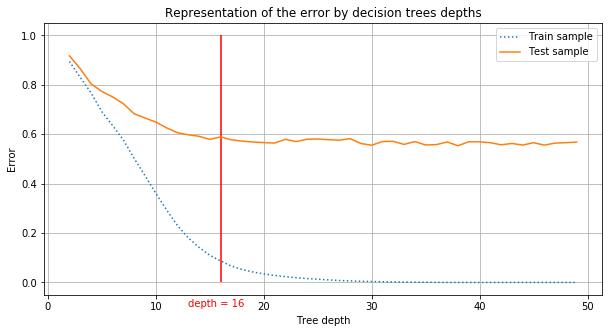

```python
# Représentation of the error by depths

plt.figure(figsize=(10, 5))
plt.plot(depths,
         train_err,
         linestyle=':',
         label="Train sample"
        )
plt.plot(depths,
         test_err,
         linestyle='-',
         label="Test sample"
        )
plt.xlabel("Tree depth")
plt.ylabel("Error")
plt.grid()
plt.legend(loc="best")
plt.vlines(x=16, ymin = 0, ymax = 1, color = "red")
plt.text( x = 13, y = -0.1, s = "depth = 16", color = "red")
plt.title("Representation of the error by decision trees depths")
```

```python
depth = 16
decision_tree_model = DecisionTreeClassifier(criterion = "gini", max_depth = depth)
decision_tree_model.fit(X_train, y_train)
```

```
DecisionTreeClassifier(ccp_alpha=0.0, class_weight=None, criterion='gini',
                       max_depth=16, max_features=None, max_leaf_nodes=None,
                       min_impurity_decrease=0.0, min_impurity_split=None,
                       min_samples_leaf=1, min_samples_split=2,
                       min_weight_fraction_leaf=0.0, presort='deprecated',
                       random_state=None, splitter='best')
```

We evaluate the score of correctness to the decision tree :

```python
score = round(100*decision_tree_model.score(X_test, y_test),2)
s = " %"
dict_score = {}
dict_score["Decision tree"]="{}{}".format(score, s)

print(dict_score)
```

```
{'Decision tree': '41.33 %'}
```

### Bagging

We build a bagging model, that agregates the decision trees generated using a bootstrapped train sample for each tree.

```python
from sklearn.ensemble import BaggingClassifier

# Initializing the base decision tree classifier
base_cls = DecisionTreeClassifier()

# Number of base classifiers
number_base_cls = 100

# Bagging classifier
bagging_model = BaggingClassifier(base_estimator = base_cls,
                          n_estimators = number_base_cls,
                          random_state = 42)

# Training
bagging_model.fit(X_train, y_train)
```

```
BaggingClassifier(base_estimator=DecisionTreeClassifier(ccp_alpha=0.0,
                                                        class_weight=None,
                                                        criterion='gini',
                                                        max_depth=None,
                                                        max_features=None,
                                                        max_leaf_nodes=None,
                                                        min_impurity_decrease=0.0,
                                                        min_impurity_split=None,
                                                        min_samples_leaf=1,
                                                        min_samples_split=2,
                                                        min_weight_fraction_leaf=0.0,
                                                        presort='deprecated',
                                                        random_state=None,
                                                        splitter='best'),
                  bootstrap=True, bootstrap_features=False, max_features=1.0,
                  max_samples=1.0, n_estimators=100, n_jobs=None,
                  oob_score=False, random_state=42, verbose=0,
                  warm_start=False)
```

```python
score = round(100*bagging_model.score(X_test, y_test),2)
dict_score["Bagging Decision Tree"]="{}{}".format(score, s)
print(dict_score)
```

```
{'Decision tree': '41.33 %', 'Bagging Decision Tree': '73.09 %'}
```

The bagging significantly increases the score of correctness checked with the validation sample.

### Boosting

We generate a boosting model using decision trees. The idea is to create several subsets of data from a randomly selected training sample with replacement. Each subset data collection is then used for old decision trees. As a result, we end up with a set of different models. The average of all the predictions from different trees is used, which is more robust than a single decision tree.

```python
from sklearn.ensemble import AdaBoostClassifier

# Initializing the base decision tree classifier
base_cls = DecisionTreeClassifier(max_depth=20)

# Number of base classifiers
number_base_cls = 50

# bagging classifier
adaboost_model = AdaBoostClassifier(base_estimator = base_cls,
                          n_estimators = number_base_cls,
                          random_state = 33)

adaboost_model.fit(X_train, y_train)
```

```
AdaBoostClassifier(algorithm='SAMME.R',
                   base_estimator=DecisionTreeClassifier(ccp_alpha=0.0,
                                                         class_weight=None,
                                                         criterion='gini',
                                                         max_depth=20,
                                                         max_features=None,
                                                         max_leaf_nodes=None,
                                                         min_impurity_decrease=0.0,
                                                         min_impurity_split=None,
                                                         min_samples_leaf=1,
                                                         min_samples_split=2,
                                                         min_weight_fraction_leaf=0.0,
                                                         presort='deprecated',
                                                         random_state=None,
                                                         splitter='best'),
                   learning_rate=1.0, n_estimators=50, random_state=33)
```

```python
score = round(100*adaboost_model.score(X_test, y_test),2)
dict_score["Boosting Decision Tree"]="{}{}".format(score, s)
print(dict_score)
```

```
{'Decision tree': '41.33 %', 'Bagging Decision Tree': '73.09 %', 'Boosting Decision Tree': '72.35 %'}
```

The boosting shows similar performances to bagging.

### Extra Trees

We introduce randomness in the selection of variables as well as the discrimination threshold at each node of the decision trees.

```python
from sklearn.ensemble import ExtraTreesClassifier

extra_trees_model = ExtraTreesClassifier( random_state = 42 )
extra_trees_model.fit(X_train, y_train)
```

```
ExtraTreesClassifier(bootstrap=False, ccp_alpha=0.0, class_weight=None,
                     criterion='gini', max_depth=None, max_features='auto',
                     max_leaf_nodes=None, max_samples=None,
                     min_impurity_decrease=0.0, min_impurity_split=None,
                     min_samples_leaf=1, min_samples_split=2,
                     min_weight_fraction_leaf=0.0, n_estimators=100,
                     n_jobs=None, oob_score=False, random_state=42, verbose=0,
                     warm_start=False)
```

```python
score = round(100*extra_trees_model.score(X_test, y_test),2)
dict_score["Extra trees"]="{}{}".format(score, s)
print(dict_score)
```

```
{'Decision tree': '41.33 %', 'Bagging Decision Tree': '73.09 %', 'Boosting Decision Tree': '72.35 %', 'Extra trees': '80.3 %'}
```

### Random Forests

Once again we introduce randomness in selection of variables, and also in the constitution of the train sample for each decision tree by boostrapping it.

```python
from sklearn.ensemble import RandomForestClassifier

rf_model = RandomForestClassifier(random_state = 36)
rf_model.fit(X_train, y_train)
```

```
RandomForestClassifier(bootstrap=True, ccp_alpha=0.0, class_weight=None,
                       criterion='gini', max_depth=None, max_features='auto',
                       max_leaf_nodes=None, max_samples=None,
                       min_impurity_decrease=0.0, min_impurity_split=None,
                       min_samples_leaf=1, min_samples_split=2,
                       min_weight_fraction_leaf=0.0, n_estimators=100,
                       n_jobs=None, oob_score=False, random_state=36, verbose=0,
                       warm_start=False)
```

```python
score = round(100*rf_model.score(X_test, y_test),2)
dict_score["Random Forests"]="{}{}".format(score, s)
print(dict_score)
```

```
{'Decision tree': '41.33 %', 'Bagging Decision Tree': '73.09 %', 'Boosting Decision Tree': '72.35 %', 'Extra trees': '80.3 %', 'Random Forests': '81.58 %'}
```

## Part 4 : Neural Network

We will compare the performance of different networks. Given the nature of the data (images), all the networks considered are convolutional networks. Moreover, performances can vary according to the optimization algorithm. Therefore, the models do not all have the same solver.

Reshape of data :

```python
num_classes = 26
img_rows, img_cols = 28, 28

x_train = pd.read_csv("/content/sign_mnist_train.csv")
x_test = pd.read_csv("/content/sign_mnist_test.csv")

labels = x_train['label']
x_train.drop('label', axis=1, inplace=True)
labels_test = x_test['label']
x_test.drop('label', axis=1, inplace=True)

x_train = np.asarray(x_train)
x_test = np.asarray(x_test)

if backend.image_data_format() == 'channels_first':
    x_train = x_train.reshape(x_train.shape[0], 1, img_rows, img_cols)
    x_test = x_test.reshape(x_test.shape[0], 1, img_rows, img_cols)
    input_shape = (1, img_rows, img_cols)
else:
    x_train = x_train.reshape(x_train.shape[0], img_rows, img_cols, 1)
    x_test = x_test.reshape(x_test.shape[0], img_rows, img_cols, 1)
    input_shape = (img_rows, img_cols, 1)

x_train = x_train.astype('float32')
x_test = x_test.astype('float32')

# One normalize the data to [-1,1]

x_train = (x_train - 127.5) / 127.5
x_test = (x_test - 127.5) / 127.5

y_train = utils.to_categorical(labels.values, num_classes)

y_test = utils.to_categorical(labels_test.values, num_classes)
```

As seen in the previous section, all the methods that are simple do not perform well on our data.

Moreover because our data are pictures, they have local structure so Convolutional Network are particularry well suited for this kind of applications.

That is why we concentrate our work on this type of network.

### Convolutional Network

We tried three different networks. The first one is a three layers CNN, while the two other are four layers CNN. The main difference between the two last is the number of parameters. While the CNN number two as a very view number of parameters, the last one as more than a million one.

```python
def three_layers_cnn(num_classes):

  model = Sequential()
  model.add(layers.Conv2D(64, (5, 5), strides=(2, 2), padding='same',
                                      input_shape=[28, 28, 1]))
  model.add(layers.LeakyReLU())
  model.add(layers.Dropout(0.3))

  model.add(layers.Conv2D(128, (5, 5), strides=(2, 2), padding='same'))
  model.add(layers.LeakyReLU())
  model.add(layers.Dropout(0.3))

  model.add(Flatten())
  model.add(layers.Dense(num_classes , activation = 'softmax') )

  model.compile(
    # specifying the loss as the cross-entropy
    loss = losses.categorical_crossentropy,
    optimizer = optimizers.Adagrad(),
    metrics = ['accuracy'] )

  return model

three_layers_cnn_model = three_layers_cnn(num_classes)

three_layers_cnn_model.summary()
```

```
Model: "sequential_3"
_________________________________________________________________
Layer (type)                 Output Shape              Param #
=================================================================
conv2d_7 (Conv2D)            (None, 14, 14, 64)        1664
_________________________________________________________________
leaky_re_lu_2 (LeakyReLU)    (None, 14, 14, 64)        0
_________________________________________________________________
dropout_5 (Dropout)          (None, 14, 14, 64)        0
_________________________________________________________________
conv2d_8 (Conv2D)            (None, 7, 7, 128)         204928
_________________________________________________________________
leaky_re_lu_3 (LeakyReLU)    (None, 7, 7, 128)         0
_________________________________________________________________
dropout_6 (Dropout)          (None, 7, 7, 128)         0
_________________________________________________________________
flatten_3 (Flatten)          (None, 6272)              0
_________________________________________________________________
dense_5 (Dense)              (None, 26)                163098
=================================================================
Total params: 369,690
Trainable params: 369,690
Non-trainable params: 0
_________________________________________________________________
```

```python
def little_parameters_four_cnn(num_classes):
  model = Sequential()
  model.add(Conv2D(64, kernel_size=(3,3), activation = 'relu', input_shape=(28, 28 ,1) ))
  model.add(MaxPooling2D(pool_size = (2, 2)))

  model.add(Conv2D(64, kernel_size = (3, 3), activation = 'relu'))
  model.add(MaxPooling2D(pool_size = (2, 2)))

  model.add(Conv2D(64, kernel_size = (3, 3), activation = 'relu'))
  model.add(MaxPooling2D(pool_size = (2, 2)))

  model.add(Flatten())
  model.add(Dense(128, activation = 'relu'))
  model.add(Dropout(0.20))

  model.add(Dense(num_classes, activation = 'softmax'))

  model.compile(
    loss = losses.categorical_crossentropy,
    optimizer = 'nadam',
    metrics = ['accuracy'] )

  return model

little_parameters_four_cnn_model = little_parameters_four_cnn(num_classes)

little_parameters_four_cnn_model.summary()
```

```
Model: "sequential_4"
_________________________________________________________________
Layer (type)                 Output Shape              Param #
=================================================================
conv2d_9 (Conv2D)            (None, 26, 26, 64)        640
_________________________________________________________________
max_pooling2d_5 (MaxPooling2 (None, 13, 13, 64)        0
_________________________________________________________________
conv2d_10 (Conv2D)           (None, 11, 11, 64)        36928
_________________________________________________________________
max_pooling2d_6 (MaxPooling2 (None, 5, 5, 64)          0
_________________________________________________________________
conv2d_11 (Conv2D)           (None, 3, 3, 64)          36928
_________________________________________________________________
max_pooling2d_7 (MaxPooling2 (None, 1, 1, 64)          0
_________________________________________________________________
flatten_4 (Flatten)          (None, 64)                0
_________________________________________________________________
dense_6 (Dense)              (None, 128)               8320
_________________________________________________________________
dropout_7 (Dropout)          (None, 128)               0
_________________________________________________________________
dense_7 (Dense)              (None, 26)                3354
=================================================================
Total params: 86,170
Trainable params: 86,170
Non-trainable params: 0
_________________________________________________________________
```

```python
def many_parameters_four_cnn(num_classes):
  # code à réaliser dans le tp sur les reseaux de neurones pour l'exemple des pickles
  model = Sequential()
  model.add(Conv2D(32, kernel_size=(5,5), activation = 'relu', input_shape=(28, 28 ,1) ))
  model.add(MaxPooling2D(pool_size = (2, 2)))

  model.add(Conv2D(64, kernel_size = (5, 5), activation = 'relu'))
  model.add(MaxPooling2D(pool_size = (2, 2)))
  model.add(Dropout(0.25))


  model.add(Flatten())
  model.add(Dense(1024))
  model.add(Dropout(0.5))

  model.add(Dense(num_classes, activation = 'softmax'))

  model.compile(
    loss = losses.categorical_crossentropy,
    optimizer = optimizers.Adagrad(),
    metrics = ['accuracy'] )

  return model

many_parameters_four_cnn_model = many_parameters_four_cnn(num_classes)

many_parameters_four_cnn_model.summary()
```

```
Model: "sequential_5"
_________________________________________________________________
Layer (type)                 Output Shape              Param #
=================================================================
conv2d_12 (Conv2D)           (None, 24, 24, 32)        832
_________________________________________________________________
max_pooling2d_8 (MaxPooling2 (None, 12, 12, 32)        0
_________________________________________________________________
conv2d_13 (Conv2D)           (None, 8, 8, 64)          51264
_________________________________________________________________
max_pooling2d_9 (MaxPooling2 (None, 4, 4, 64)          0
_________________________________________________________________
dropout_8 (Dropout)          (None, 4, 4, 64)          0
_________________________________________________________________
flatten_5 (Flatten)          (None, 1024)              0
_________________________________________________________________
dense_8 (Dense)              (None, 1024)              1049600
_________________________________________________________________
dropout_9 (Dropout)          (None, 1024)              0
_________________________________________________________________
dense_9 (Dense)              (None, 26)                26650
=================================================================
Total params: 1,128,346
Trainable params: 1,128,346
Non-trainable params: 0
_________________________________________________________________
```

The networks have been selected such that the second one has a very low number of parameters in a way that the first one as more parameters even with less layers. So one could empirically very the fact that the most important is the number of layers and not the number of parameters (of course it is not so simple in reality).

We can now run the algorithms and compare their performance :

```python
# hyper parameters
epochs = 100
epochs2 = 200
batch_size = 100

def print_results_training(model, history, cnn_name):
  score = model.evaluate(x_test, y_test, verbose=1)
  print('Test loss:', score[0])
  print('Test accuracy:', score[1])

  plt.figure(figsize=(7, 5))
  plt.plot(history.epoch, history.history['accuracy'], lw=3, label='Training')
  plt.plot(history.epoch, history.history['val_accuracy'], lw=3, label='Testing')
  plt.legend(fontsize=14)
  plt.title('Accuracy of ' + cnn_name, fontsize=16)
  plt.xlabel('Epoch', fontsize=14)
  plt.ylabel('Accuracy', fontsize=14)
  plt.tight_layout()
```

```
Test loss: 0.6026400963703614
Test accuracy: 0.8172058
```

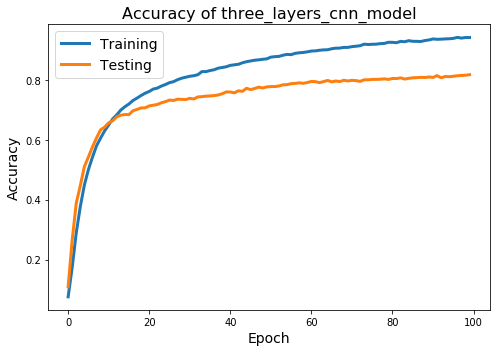

```python
history_three_layers_cnn_model = three_layers_cnn_model.fit(x_train, y_train,
                      batch_size=batch_size,
                      epochs=epochs,
                      verbose=0,
                      validation_data=(x_test, y_test))

print_results_training(three_layers_cnn_model, history_three_layers_cnn_model, 'three_layers_cnn_model')
```

```
Test loss: 0.5704890383031855
Test accuracy: 0.9478528
```

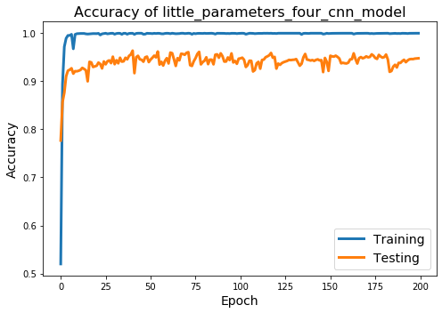

```python
history_little_parameters_four_cnn_model = little_parameters_four_cnn_model.fit(x_train, y_train,
                      batch_size=batch_size,
                      epochs=epochs2,
                      verbose=0,
                      validation_data=(x_test, y_test))

print_results_training(little_parameters_four_cnn_model, history_little_parameters_four_cnn_model, 'little_parameters_four_cnn_model')
```

```
Test loss: 0.1754702352905699
Test accuracy: 0.9510597
```

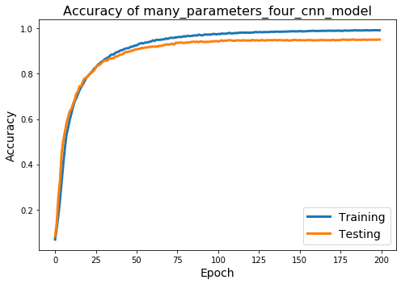

```python
history_many_parameters_four_cnn_model = many_parameters_four_cnn_model.fit(x_train, y_train,
                      batch_size=batch_size,
                      epochs=epochs2,
                      verbose=0,
                      validation_data=(x_test, y_test))

print_results_training(many_parameters_four_cnn_model, history_many_parameters_four_cnn_model, 'many_parameters_four_cnn_model')
```

As we can see, the first CNN performed less well than the others. It is expected since it has less layers than the two others.

A more interesting fact is that the two other performed relatively in a way relatively equal even if there is a million more parameters in the last one than in the second one.

This underline well the fact that the choice of the architectur of a network is something difficult.

Eventually one can underline the fact that the last two CNN performed slightly better than the others methods presented here.